# Problem_Set_1_Shivant

Shivant Maharaj

2022-11-07

# 1 Question 1

## 1.1 Text

Subtitle - 2/2 - There are markups on the graph as well as as an informative subtitle. Not left aligned.

Horizontal Text - 2/2 - All text is horizonal in the visualisation

Data Labels - 1/2 - Missing y axis label

Labels used sparingly - 1/2 - I think it is used a bit too sparingly - we are also missing the legend title

## 1.2 Arrangements

Proportions are accurate - 2/2 - The proportions match the content that the visual is trying to portray. It has both the minimum and maximum values for the y axis.

Data are intentionally ordered - 1/2 - Majority of the data displayed is ordered but the legend des not follow an alphabetical order.

Axis intervals are equidistant - 2/2 - Data is consistently ordered and 2D.

Two dimensional - 2/2

Free from decorations - 2/2 - Free from unnecessary icons

Color scheme is intentional - 1/2 - The colour palatte is not very intentional and follows the blue, turquoise and green colours.

Color is used to highlight key patterns - 0/2 - Colour is not used to highlight any findings

Color is legible when printed in black and white - 0/2 - Will be very hard to see the differences in blac and white

Color is legible for people with colorblindness - 1/2 - The color is legible for color blind individuals, but hard to distinguish

Text sufficiently contrasts background - 2/2 - High contrast is good

## 1.3 Lines

Gridlines, if present, are muted - 2/2 - Muted and required since the graph has no numeric points/anotations on it

Graph does not have border line - 2/2 - No border line

Axes do not have unnecessary tick marks or axis lines - 2/2 - No unnecessary lines

Graph has one horizontal and one vertical axis Viewers can best interpret one x- and one y-axis. - 2/2 - Only 1 axis

## 1.4 Overall

Graph highlights significant finding or conclusion - 1/2 - We can see a steep decline after the annotated emergency

The type of graph is appropriate for data - 2/2 - Yes, the line graph helps show how the different industries were affected by the emergency

Graph has appropriate level of precision - 2/2 - Precision level is suitable for the target audience

Individual chart elements work together to reinforce the overarching takeaway message - 2/2 - Yes, the graph shows that there is a consistent drop in credit card spending in all industries once the national emergency was announced.

# 2 Question 2

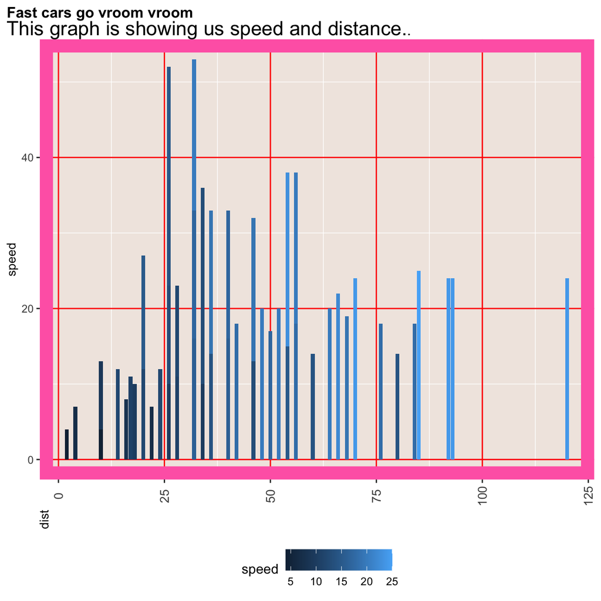

```r
ggplot(cars, aes(x = dist, y = speed, fill = speed)) +
  geom_col() +
  labs(title = "<b>Fast cars go vroom vroom</b><br>
      <span style = 'font-size:16pt'>This graph is showing us speed and distance.</span>.</span>",
      x= "dist",
      y = "speed") +
      theme(
      panel.background = element_rect(fill = "#F1E8E2"),
      plot.title.position = "plot",
      plot.title = element_textbox_simple(size=12),
      axis.title = element_text(angle = 90, vjust = 0.5,size=10),
      axis.text.x = element_text( angle = 90, vjust = 0.5,size=10),
      legend.position = "bottom", panel.border = element_rect(color = "hotpink",
                                    fill = NA,
                                    size = 10)) +
      theme(panel.grid.major=element_line(colour="red"))
```

# 3 Question 3

The Stop and Search data supplied by the UK Police website was downloaded and imported into R. Basic data cleaning was performed on the dataset.

We also glimpsed the data to have an overview of the data within the table.

```r
data <- vroom("stop-and-search.csv") %>% clean_names()

data <- data %>% mutate(date = date(date))

#skimr::skim(data)

head(data, 50)
```

```
## # A tibble: 50 × 15
##    type        date       part_…¹ polic…² latit…³ longi…⁴ gender age_r…⁵ self_…⁶
##    <chr>       <date>     <lgl>   <lgl>     <dbl>   <dbl> <chr>  <chr>   <chr>
##  1 Person and… 2022-08-31 FALSE   NA         51.5 -0.0615 Male   10-17   White …
##  2 Person sea… 2022-08-31 FALSE   NA         51.5 -0.161  Male   18-24   Black/…
##  3 Person sea… 2022-08-31 FALSE   NA         51.5 -0.161  Male   18-24   Black/…
##  4 Person sea… 2022-08-31 FALSE   NA         51.6  0.155  Male   18-24   Other …
##  5 Person and… 2022-08-31 FALSE   NA         51.6 -0.0695 Male   10-17   Black/…
##  6 Person sea… 2022-08-31 FALSE   NA         51.5 -0.133  Male   over 34 Other …
##  7 Person and… 2022-08-31 FALSE   NA         51.6 -0.0695 Male   10-17   Other …
##  8 Person sea… 2022-08-31 FALSE   NA         51.6 -0.0695 Male   over 34 Black/…
##  9 Person and… 2022-08-31 FALSE   NA         51.6 -0.0695 Male   10-17   Other …
## 10 Person sea… 2022-08-31 FALSE   NA         51.5 -0.0550 Male   over 34 Black/…
## # … with 40 more rows, 6 more variables: officer_defined_ethnicity <chr>,
## #   legislation <chr>, object_of_search <chr>, outcome <chr>,
## #   outcome_linked_to_object_of_search <lgl>,
## #   removal_of_more_than_just_outer_clothing <lgl>, and abbreviated variable
## #   names ¹part_of_a_policing_operation, ²policing_operation, ³latitude,
## #   ⁴longitude, ⁵age_range, ⁶self_defined_ethnicity
```

## 3.1 Plot 1

The following plot shows the frequency of the various search and stop reasons.

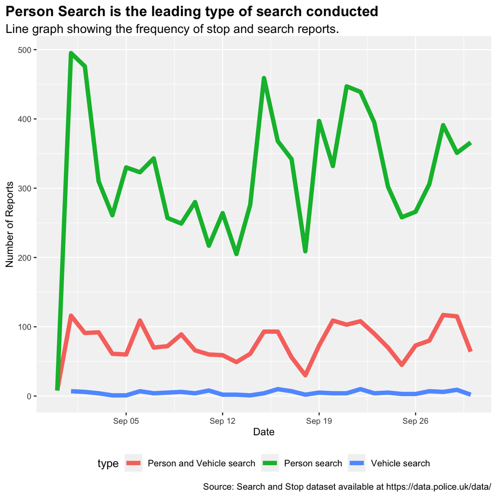

```r
data_q1 <- data %>%
  group_by(type, date) %>%
  summarise(count = n())

#data_q1

ggplot(data_q1, aes(x = date, y = count, colour = type)) +
  geom_line(size = 2) +
  labs(title = "<b>Person Search is the leading type of search conducted</b><br>
      <span style = 'font-size:12pt'>Line graph showing the frequency of stop and search reports</span>.</span>",
      x= "Date",
      y = "Number of Reports",
      caption = "Source: Search and Stop dataset available at https://data.police.uk/data/") +
      theme(
      panel.background = element_rect(fill = "#F3F3F3"),
      plot.title.position = "plot",
      plot.title = element_textbox_simple(size=14),
      axis.title = element_text(angle = 0, vjust = 0.5,size=10),
      axis.text = element_text( angle = 0, vjust = 0.5,size=8),
      legend.position = "bottom")
```

## 3.2 Plot 2

Tje following plot shows the distribution of search and stop occurences per day of the week. I believe this shows a trend that increases the closer it gets to the weekend. This could be due to the reason that there is more activity as the week progresses.

[figure not shown]

```r
q2_c <- c("#0fa3b1", "#454b66", "#ed6a5a")

q2 <- data %>%
  mutate(day = wday(date)) %>%
  mutate(day_text = case_when(day == 1 ~ "Monday",
                              day == 2 ~ "Tuesday",
                              day == 3 ~ "Wednesday",
                              day == 4 ~ "Thursday",
                              day == 5 ~ "Friday",
                              day == 6 ~ "Saturday",
                              day == 7 ~ "Sunday")) %>%
  group_by(day_text, type) %>%
  summarise(count = n()) %>%
  mutate(day_text=factor(day_text, levels=c("Monday", "Tuesday", "Wednesday", "Thursday", "Friday", "Saturday", "Sunday"))) %>%
  arrange(day_text)

ggplot(q2, aes(x = day_text, y = count, fill = type)) +
  geom_col() +
  scale_fill_manual(values = q2_c) +
  scale_x_discrete(guide = guide_axis(n.dodge=2)) +
  labs(title = "<b>More people are stopped and searched on a Friday</b><br>
      <span style = 'font-size:12pt'>Bar graph showing the frequency of stop and search reports per day of the week</span>.</span>",
      x= "Day of the Week",
      y = "Count",
      caption = "Source: Search and Stop dataset available at https://data.police.uk/data/") +
      theme(
      plot.title.position = "plot",
      plot.title = element_textbox_simple(size=14),
      axis.title = element_text(angle = 0, vjust = 0.5,size=10),
      axis.text = element_text( angle = 0, vjust = 0.5,size=8),
      legend.position = "right",
      panel.background = element_rect(fill = "#F3F3F3"))
```

## 3.3 Plot 3

An analysis into the underage stop and search calls was conducted to understand the top reasons why teenagers are investigated.

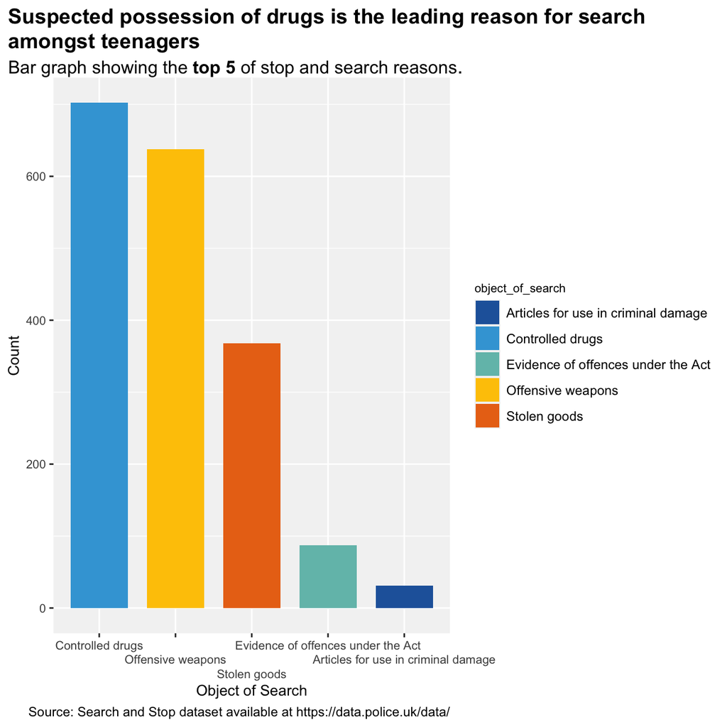

```r
q3 <- data %>%
  filter(age_range =="10-17") %>%
  group_by(object_of_search) %>%
  summarise(count = n()) %>%
  slice_max(count, n = 5)

q3_c = c("#2364AA", "#3DA5D9", "#73BFB8", "#FEC601", "#EA7317")
ggplot(q3, aes(x = fct_inorder(object_of_search), y = count, fill = object_of_search)) +
  geom_col(width = 0.75) +
  scale_fill_manual(values = q3_c) +
  scale_x_discrete(guide = guide_axis(n.dodge=3)) +
  labs(title = "<b>Suspected possession of drugs is the leading reason for search amongst teenagers</b><br>
      <span style = 'font-size:12pt'>Bar graph showing the <b>top 5</b> of stop and search reasons</span>.</span>",
      x = "Object of Search",
      y = "Count",
      caption = "Source: Search and Stop dataset available at https://data.police.uk/data/",
      legend = "Object of Search") +
      theme(
      panel.background = element_rect(fill = "#F3F3F3"),
      plot.title.position = "plot",
      plot.title = element_textbox_simple(size=14),
      axis.title = element_text(angle = 0, vjust = 0.5,size=10),
      axis.text = element_text( angle = 0, vjust = 0.5,size=8),
      legend.position = "right",
      legend.title = element_text( angle = 0, vjust = 0.5,size=8))
```

# 4 Extra Credit for Q2

## 4.1 I did not intend on making this - but it happened naturally…

The following visualisation was created while I was trying to create a ggmap of the UK.

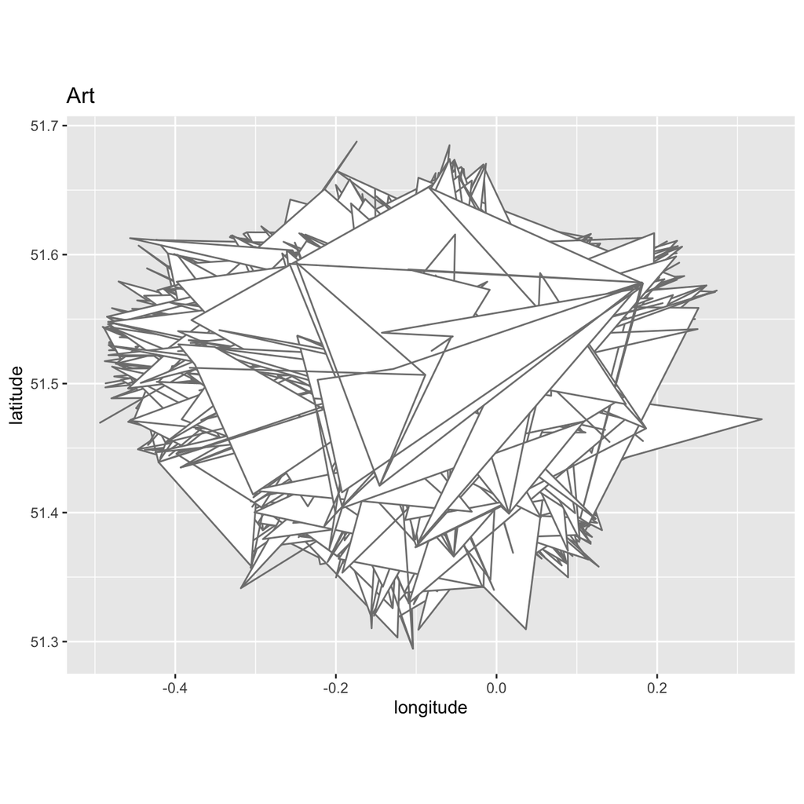

```r
#For extra credit - this graph is also really bad

ggplot(data, aes(x=longitude, y=latitude)) +
  geom_polygon(fill = "white", colour = "grey50") +
  coord_quickmap() +
  labs(title = "Art")
```